# Technical report

Ramon Rotaeche y Lluís Bernat

11/06/2021

# Análisis descriptivo de la serie

El *dataset* contiene 1463 puntos con los tres campos siguientes:

- ‘Series’, de tipo alfanumérico con el literal `Potència activa`
- ‘Time’, marca de tiempo (*timestamp*) conforme a la especificación descrita en la RFC3339
- ‘Value’, numérico entero positivo. Representa la **potencia activa** acumulada en el período de muestreo. Unidades: VA.

Como primer paso de nuestro análisis vamos a cargar y representar gráficamente la serie:

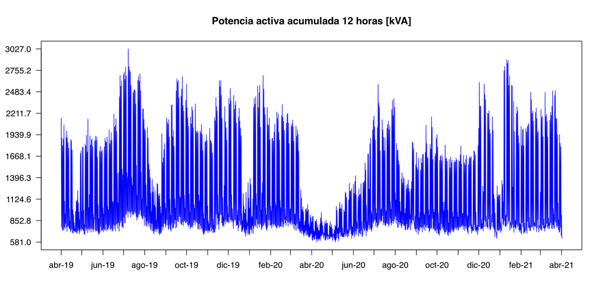

```r
# Por si queremos asegurarnos que los meses se escriben en castellano
#Sys.setlocale("LC_TIME", "es_ES.UTF-8")
# Es un csv
serie <- read.csv(file = 'data/potencia.csv', sep = ';')
# La marca de tiempo está en hora legal española, así que
# siguiendo las buenas prácticas, la convertimos a UTC
t <- as.POSIXct(serie$Time, format = "%Y-%m-%dT%H:%M:%S", tz = "Europe/Madrid")
t <- as.POSIXlt(t, format = "%Y-%m-%dT%H:%M:%S", tz = "GMT")
# También construimos un vector con los valores de potencia activa acumulada
VA <- as.numeric(serie$Value)
# Finalmente un dibujo para comprender mejor la serie
plot(t, VA, type="l", main = "Potencia activa acumulada 12 horas [kVA]",
     col="blue", xaxt="n", yaxt="n", xlab = "", ylab = "")
axis.POSIXct(side = 1, at = seq(min(t), max(t), by = "months"), format = "%b-%y", las = 1)
yticks <- seq(min(VA), max(VA), length.out = 10)
axis(side = 2, at = yticks, labels = formatC(yticks / 1000, format = "f", digits = 1), las = 2)
```

## Coherencia de la serie

Para asegurar que los siguientes análisis funcionan efectuaremos una comprobación de integridad de los datos.

En primer lugar conviene saber si tenemos todas las muestras, pues la falta de alguna puede arrojar resultados extraños. En caso de que faltasen algunas de forma diseminada, las podríamos completar interpolando con las vecinas que fueran de la misma hora por ejemplo. Veamos que valen la primera y la última marca temporal de la serie, así como el número de muestras:

```r
min(t); max(t); length(t)
```

```
## [1] "2019-04-01 GMT"
```

```
## [1] "2021-04-01 12:00:00 GMT"
```

```
## [1] 1463
```

Vemos que deberíamos tener dos años completos de datos. Es decir (365 + 366 + 1)x2 = 1464 valores en la serie. Sin embargo, tenemos 1463, es decir nos falta un dato.

Después de un análisis más profundo vemos que el dato que falta corresponde a la tarde del domingo del 07-06-2020. Creamos ese valor y le damos el mismo valor de VA que la tarde del día anterior (que es sábado). Usamos ahora el *dataset* corregido

```r
serie <- read.csv(file = 'data/potencia_corr.csv', sep = ';')
t <- as.POSIXct(serie$Time, format = "%Y-%m-%dT%H:%M:%S", tz = "Europe/Madrid")
t <- as.POSIXlt(t, format = "%Y-%m-%dT%H:%M:%S", tz = "GMT")
VA <- as.numeric(serie$Value)
```

Ahora que tenemos el eje temporal completo, repasaremos la coherencia de los valores VA de la serie. En principio, un examen de la gráfica del punto anterior nos permite observar que todos los valores están en el intervalo de 581 kVA a 3027 kVA y que por lo tanto no hay valores negativos, que serían a todas luces imposibles. Aún así lo podemos certificar con un sencillo comando de *R*:

```r
# Cual es el intervalo de VA?
c(min(VA), max(VA))
```

```
## [1]  581000 3027000
```

También debemos comprobar la no existencia de puntos atípicos (*outliers*):

```r
# Veamos cuales son los cuartiles
quar <- quantile(VA)
# Calculamos la amplitud entre el segundo y cuarto (25% y 75%)
upperq = quar[4]
lowerq = quar[2]
iqam = upperq - lowerq
# Será nuestra referencia para calcular los límites *razonables*
# Un criterio común es tolerar un +150% del valor inter-cuartil 25%-75%
upperbound = upperq + (1.5 * iqam)
lowerbound = max(lowerq - (1.5 * iqam), 0)
result <- which(VA > upperbound | VA < lowerbound)
print(result)
```

```
## [1] 197
```

Tenemos un solo punto atípico a corregir. Seguramente no distorsione el resultado, pues se trata de un solo valor:

```r
print(cbind(result, VA[result]))
```

```
##      result
## [1,]    197 3027000
```

Aún así y a fin de reforzar la teoría aprendida, le aplicaremos una técnica de suavizado muy sencilla que consistirá en sustituir su valor por el promedio de sus vecinos. Debido a que tenemos lecturas alternas correspondientes a mediodía y medianoche, tiene sentido considerar que sus vecinos son la muestra antecesora de la antecesora (i.e. anterior en dos unidades) y la sucesora de la sucesora (es decir la posterior en dos unidades). Esto lo haremos con el siguiente código que hemos diseñado para un caso más general en el que pudiesen existir muchos puntos a suavizar:

```r
if(length(result) > 0) {
  # poblaremos una matriz de n filas y 3 columnas
  # columna 1: índice del vecino a su izquierda
  # columna 2: índice de la muestra a reemplazar (*outlier*)
  # columna 3: índice del vecino a su derecha
  neighbours <- array(NA, dim = c(length(result), 3))
  j = 1
  for(i in result) {
    neighbours[j, 1] = i - 2
    neighbours[j, 2] = i
    neighbours[j, 3] = i + 2
    j = j + 1
  }
  # Vigilamos que el primer vecino no se salga del índice
  if(neighbours[1, 1] < 1)
    neighbours[1, 1] = 1
  # Vigilamos que el último vecino tampoco no se salga del índice
  if(neighbours[nrow(neighbours), 3] > length(VA))
    neighbours[nrow(neighbours), 3] = length(VA)
  print(neighbours)
}
```

```
##      [,1] [,2] [,3]
## [1,]  195  197  199
```

Veamos como ha quedado la matriz con las posiciones a suavizar y los vecinos.

```r
if(nrow(neighbours) > 0) {
  print(array(VA[neighbours], dim = c(nrow(neighbours), 3)))
  }
```

```
##         [,1]    [,2]    [,3]
## [1,] 1402000 3027000 2804000
```

Ejecutamos ahora la sustitución:

```r
if(nrow(neighbours) > 0) {
  for(i in 1:nrow(neighbours)) {
    # Hacemos la media de las dos lecturas
    # usando la división entera, porque la serie
    # no tiene valores decimales
    VA[neighbours[2]] = (VA[neighbours[1]] + VA[neighbours[3]]) %/% 2
  }
  print(array(VA[neighbours], dim = c(nrow(neighbours), 3)))
}
```

```
##         [,1]    [,2]    [,3]
## [1,] 1402000 2103000 2804000
```

Con este método hemos eliminado los puntos atípicos (*outliers*) de nuestra serie. Pasemos ahora a su análisis descriptivo.

## Estacionalidad

Observamos tres fenómenos estacionales diferentes, que se diferencian por el periodo de cada uno.

### Estacionalidad intra-día

Disponemos de dos puntos para cada día, que se dividen en dos períodos de 12 horas:

- **Mañana**: corresponde a la potencia acumulada desde las 1 ó 2 AM (hora legal península y *Illes Balears*), hasta las 1 ó 2 PM (es decir desde las 00:00h a las 12:00h UTC)
- **Tarde**: corresponde a la potencia acumulada desde la 1 ó 2 PM (hora legal), hasta la 1 ó 2 AM (el período de tiempo complementario al anterior)

Como se observa en el gráfico a continuación, el **consumo es consistentemente mayor en el periodo de tarde**. Posibles explicaciones para este fenómeno son:

- El periodo de tarde comprende más horas de clase (si entendemos que puede haber clase entre las 9.00 y las 21.00), que es cuando más alumnos hay y por tanto cuando hay un mayor uso de las instalaciones.
- Algunas instalaciones tienen un uso más intensivo a partir de la 1pm / 2pm. Por ejemplo la iluminación en invierno y el A/C en verano (porque las horas de la mañana son más frescas). También la cafetería (que puede que sea responsable de una buena parte del consumo por los electrodomésticos para cocinar, y lavar vajillas).

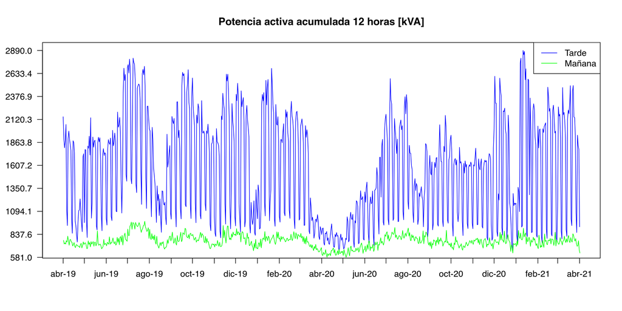

```r
# Convertimos a UTC para filtrar las lecturas
# Y construimos dos vectores auxiliares para distinguir
# los consumos de mañana y tarde
tarde <- t$hour == 0 # 00h UTC
manana <- tarde == F
# Otra representación de ambos consumos nos puede ayudar
plot(t[tarde], VA[tarde], type="l",
     main = "Potencia activa acumulada 12 horas [kVA]",
     col="blue", xaxt="n", yaxt="n",
     ylab="", xlab="")
lines(t[manana], VA[manana],col="green")
axis.POSIXct(side = 1, at = seq(min(t), max(t), by = "months"), format = "%b-%y", las = 1)
yticks <- seq(min(VA), max(VA), length.out=10)
axis(side = 2, at = yticks, labels = formatC(yticks / 1000, format = "f", digits = 1), las = 2)
legend("topright", legend=c("Tarde", "Mañana"), lty=1, col=c("blue", "green"))
```

### Estacionalidad intra-semana

Como era de esperar, hay una **diferencia bastante grande entre el consumo durante los días de semana y fin de semana**.

Sin embargo, como se puede ver en los gráficos a continuación, esta diferencia **solo se observa en el periodo de tarde**. Creemos que esto es así porque, como decíamos en el apartado anterior, la mayor parte de las horas de clase están incluidas en el periodo de tarde. Y además es en este periodo donde se usan más intensivamente algunas instalaciones (ej. iluminación). Por tanto, el efecto de la ausencia de alumnos durante fin de semana se nota más en el periodo de tarde.

- Mañana: corresponde a la potencia acumulada desde la 1 ó 2 AM (depende del momento del año), hasta las 1 ó 2 PM (0h-12h UTC)
- Tarde: corresponde a la potencia acumulada desde la 1 ó 2 PM (depende del momento del año), hasta la 1 ó 2 AM (12h-24h UTC)

Veamos la diferencia entre semana y fin de semana en el periodo de tarde:

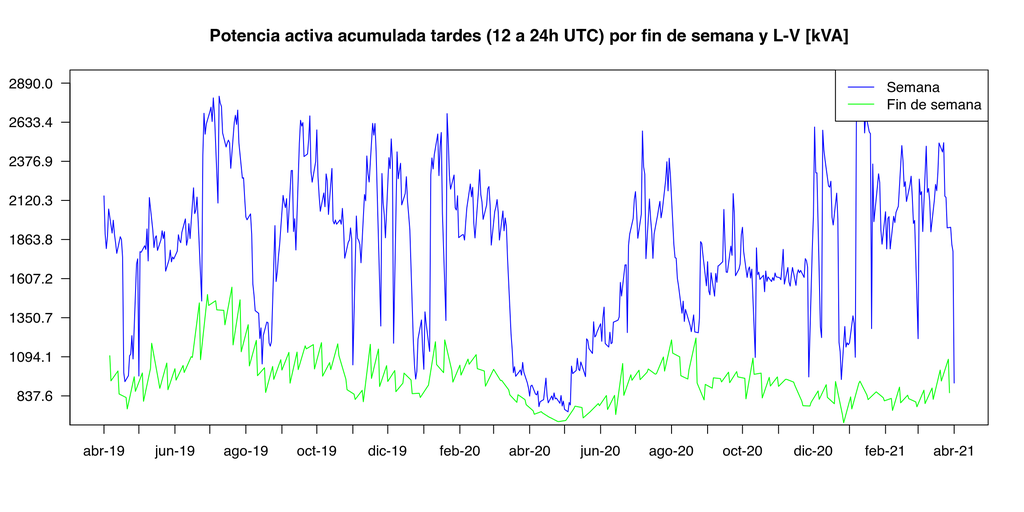

```r
# Construimos unos vectores para poder filtrar el fin de semana y los laborables
# lunes a viernes
weekend <- t$wday %in% c(0, 6)
weekday <- weekend == F
plot(t[tarde & weekday], VA[tarde & weekday], type="l",
     main = "Potencia activa acumulada tardes (12 a 24h UTC) por fin de semana y L-V [kVA]",
     col = "blue", xaxt = "n", yaxt = "n",
     ylab = "", xlab = "")
lines(t[tarde & weekend], VA[tarde & weekend], col = "green")
axis.POSIXct(side = 1, at = seq(min(t), max(t), by = "months"), format = "%b-%y", las = 1)
yticks <- seq(min(VA), max(VA), length.out=10)
axis(side = 2, at = yticks, labels = formatC(yticks / 1000, format = "f", digits = 1), las = 2)
legend("topright", legend=c("Semana", "Fin de semana"), lty=1, col=c("blue", "green"))
```

Y en el periodo de mañana:

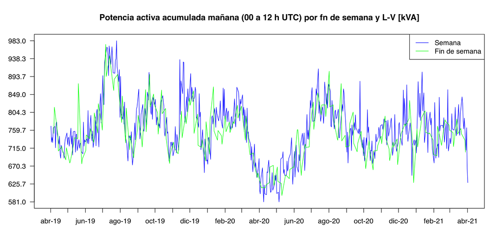

```r
plot(t[manana & weekday], VA[manana & weekday], type="l",
     main = "Potencia activa acumulada mañana (00 a 12 h UTC) por fn de semana y L-V [kVA]",
     col="blue", xaxt="n", yaxt="n",
     ylab="", xlab="")
lines(t[manana & weekend], VA[manana & weekend],col="green")
axis.POSIXct(1,at=seq(min(t), max(t), by="months"), format="%b-%y", las = 1)
yticks <- seq(min(VA), max(VA[manana & weekday]), length.out=10)
axis(2, at=yticks, labels=formatC(yticks / 1000, format="f", digits = 1), las = 2)
legend("topright", legend=c("Semana", "Fin de semana"), lty=1, col=c("blue", "green"))
```

En el periodo de mañana, no hay mucha diferencia. posiblemente por las razones comentadas arriba.

Además, como se ve en el gráfico de abajo, en el periodo de tarde, aunque hay una clara diferencia entre semana y fin de semana, ambos consumos evolucionan a la par durante el año (excepto en el periodo pandemia). Por lo que hay **un ratio más o menos constante entre el consumo en fin de semana y en semana** (en el caso del periodo de mañana ese ratio es ~1).

Nota: las dos caídas grandes en enero de 2020 y de 2021 se deben a que las semana final del año y la de inicio del siguiente año no son completas.

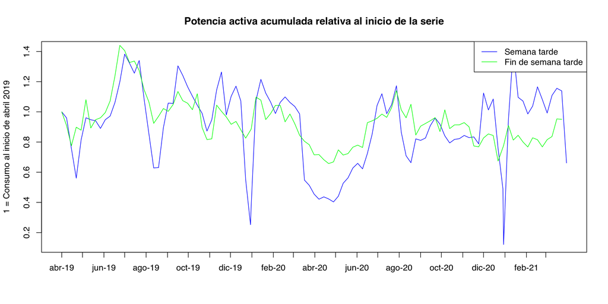

```r
num_semana = data.frame(week=strftime(t,format="%W"))
datef= data.frame(date=strftime(t,format="%Y-%d-%d"))
year = data.frame(year=strftime(t,format="%Y"))
tardef = data.frame(tarde=tarde)
weekdayf = data.frame(weekday=weekday)
VA_agg = aggregate(VA, by=c(num_semana, year, tardef, weekdayf), FUN=sum)
VA_agg$date <- as.Date((c(VA_agg$week) - 1)*7 + (c(VA_agg$year) - 1)*365, origin = "2018/12/31")
VA_tarde_semana = VA_agg[(VA_agg$tarde==TRUE & VA_agg$weekday==TRUE), ]
VA_tarde_finsemana = VA_agg[(VA_agg$tarde==TRUE & VA_agg$weekday==FALSE), ]

plot(VA_tarde_semana$date, VA_tarde_semana$x/VA_tarde_semana$x[1], type="l",
     main = "Potencia activa acumulada relativa al inicio de la serie",
     col="blue", xaxt="n", ylab="1 = Consumo al inicio de abril 2019", xlab="")
lines(VA_tarde_finsemana$date, VA_tarde_finsemana$x/VA_tarde_finsemana$x[1],col="green")
axis.Date(1,at=seq(min(VA_agg$date), max(VA_agg$date), by="months"), format="%b-%y")
legend("topright", legend=c("Semana tarde", "Fin de semana tarde"), lty=1, col=c("blue", "green"))
```

### Estacionalidad intra-año

Si visualizamos los tres años de datos con la misma referencia temporal, se observa una clara estacionalidad intra-año, como era de esperar.

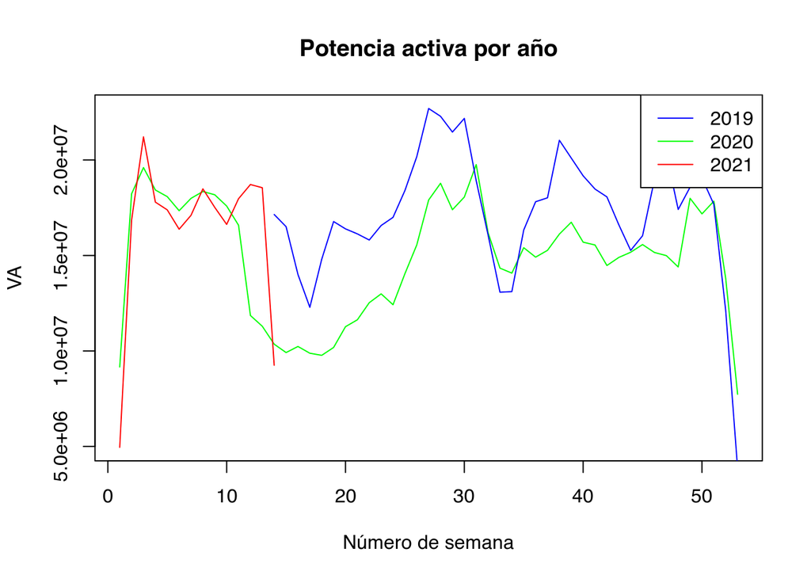

```r
VA_aggr2 = aggregate(VA, by=c(num_semana, year), FUN=sum)
VA2019 = VA_aggr2[(VA_aggr2$year == 2019),]
VA2020 = VA_aggr2[(VA_aggr2$year == 2020),]
VA2021 = VA_aggr2[(VA_aggr2$year == 2021),]
plot(c(VA2020$week), VA2020$x, type="l",
     main = "Potencia activa por año",
     col="green", ylab="VA", xlab="Número de semana",
     ylim=c(min(VA2021$x),max(VA2019$x)))
lines(VA2019$week, VA2019$x,col="blue")
lines(VA2021$week, VA2021$x,col="red")
legend("topright", legend=c("2019", "2020", "2021"), lty=1, col=c("blue", "green", "red"))
```

## Resto de componentes

### Tendencia a la largo plazo

Consideramos que no disponemos de una longitud suficiente como para analizar ninguna tendencia a largo plazo como podría ser la reducción del consumo por la mejora de la eficiencia energética o, al contrario, el crecimiento del consumo por el aumento del número de alumnos.

### Componente cíclico

Observando los datos y el contexto, creemos que en la serie se distingue claramente el impacto de la pandemia. Sobre todo en los meses de marzo - julio de 2020, pero también en lo que resta de 2020 y 2021.

Podríamos definir tres ciclos:

- “Business as usual (BAU)”: periodos en los que no se aprecia ningún fenómeno cíclico que impacte en el consumo de energía (abril 2019 - febrero 2020; enero 2021 - marzo 2021)
- “Pandemia”: periodos en los que el consumo ha caído en picado debido al confinamiento (marzo - julio 2020)
- “Estado de alarma”: periodos en los que el consumo es mayor que durante el confinamiento pero menor que en BAU por las restricciones (agosto 2020 - diciembre 2020). Para afirmar a ciencia cierta esto último, necesitaríamos una serie más larga. Pues ahora mismo no podemos confirmar que el consumo en 2021 sea igual al de BAU (aunque los primeros meses es igual que en el 2020 pre-pandemia)

### Componente estocástico

Este componente corresponde a la variación del consumo eléctrico debido a cuestiones aleatorias o pseudo-aleatorias como la temperatura concreta de un día, el número de alumnos que asisten al centro, etc. Es más complejo de modelar.

# Ajuste de un modelo para predicciones

Como resultado del análisis anterior, decidimos que:

- El modelo que es más útil ajustar de cara al futuro es que corresponde al ciclo BAU. Como tenemos un año completo de BAU, cogemos los periodos correspondientes.
- Hemos visto que hay estacionalidad intra-dia, intra-semana e intra-anual. Para lidiar con la estacionalidad intra-dia e intra-semana, eliminamos su impacto usando una **rolling average** que se expande 14 periodos (i.e. una semana de datos)
- La estacionalidad intra-anual la vamos a modelar ajustando un modelo quadrático, pero además vamos a incluir variables **“dummy” que capturen las diferencias de cada mes**. Aplicamos una **rolling average** a las *dummies* para suavizar su efecto (que además es más realista, porque no hay cambios súbitos de las condiciones entre el 31 de mayo y el 1 de junio, por ejemplo)
- Además, dado el claro impacto de las vacaciones, usamos una **variable dummy para modelar los periodos de vacaciones** de navidad, semana santa y verano

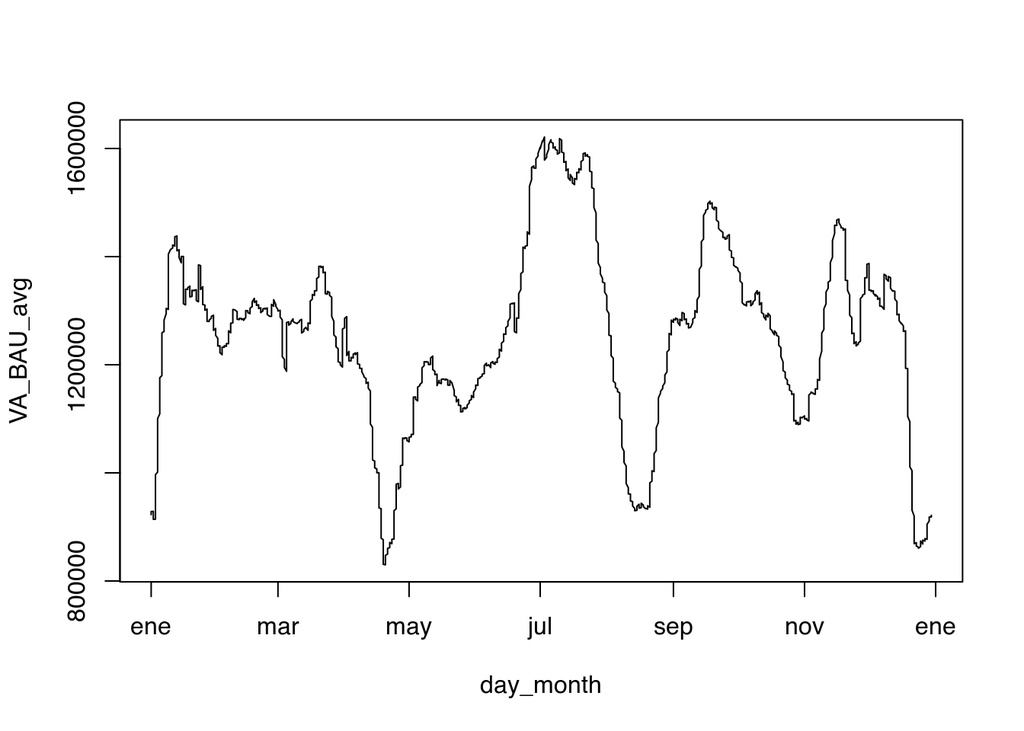

```r
# Construcción de la serie de un año BAU
VA_BAU = VA[t$year == 119 | (t$year == 120 & (t$mon < 2)) | (t$year == 121 & (t$mon >= 2))]
VA_BAU = VA_BAU[1:728] # 52 semanas justas
t_BAU = t[t$year == 119 | (t$year == 120 & (t$mon < 2)) | (t$year == 121 & (t$mon >= 2))]
t_BAU = t_BAU[1:728] # 52 semanas justas
nday = strftime(t_BAU,format="%j")
VA_BAU = VA_BAU[order(nday)]
VA_BAU_avg <- filter(VA_BAU, filter = rep(1/14,14), circular = TRUE)
day_month = as.Date(rep(c(1:364),each=2), origin = "2020/12/31") # El año nos da igual
plot(day_month, VA_BAU_avg, type="l")
```

```r
#Creación de las dummies
vacaciones_dummy_avg = (VA_BAU_avg < 10e5)*1
vacaciones_dummy_avg <- filter(vacaciones_dummy_avg, filter = rep(1/14,14), circular = TRUE)

month_avg = as.integer(strftime(day_month,format="%m"))
m1_dummy_avg = (month_avg == 1)*1; m1_dummy_avg = filter(m1_dummy_avg, filter=rep(1/14,14), circular = TRUE)
m3_dummy_avg = (month_avg == 3)*1; m3_dummy_avg = filter(m3_dummy_avg, filter=rep(1/14,14), circular = TRUE)
m5_dummy_avg = (month_avg == 5)*1; m5_dummy_avg = filter(m5_dummy_avg, filter=rep(1/14,14), circular = TRUE)
m7_dummy_avg = (month_avg == 7)*1; m7_dummy_avg = filter(m7_dummy_avg, filter=rep(1/14,14), circular = TRUE)
m9_dummy_avg = (month_avg == 9)*1; m9_dummy_avg = filter(m9_dummy_avg, filter=rep(1/14,14), circular = TRUE)
m11_dummy_avg = (month_avg == 11)*1; m11_dummy_avg = filter(m11_dummy_avg, filter=rep(1/14,14), circular = TRUE)
```

## Ajuste de la serie

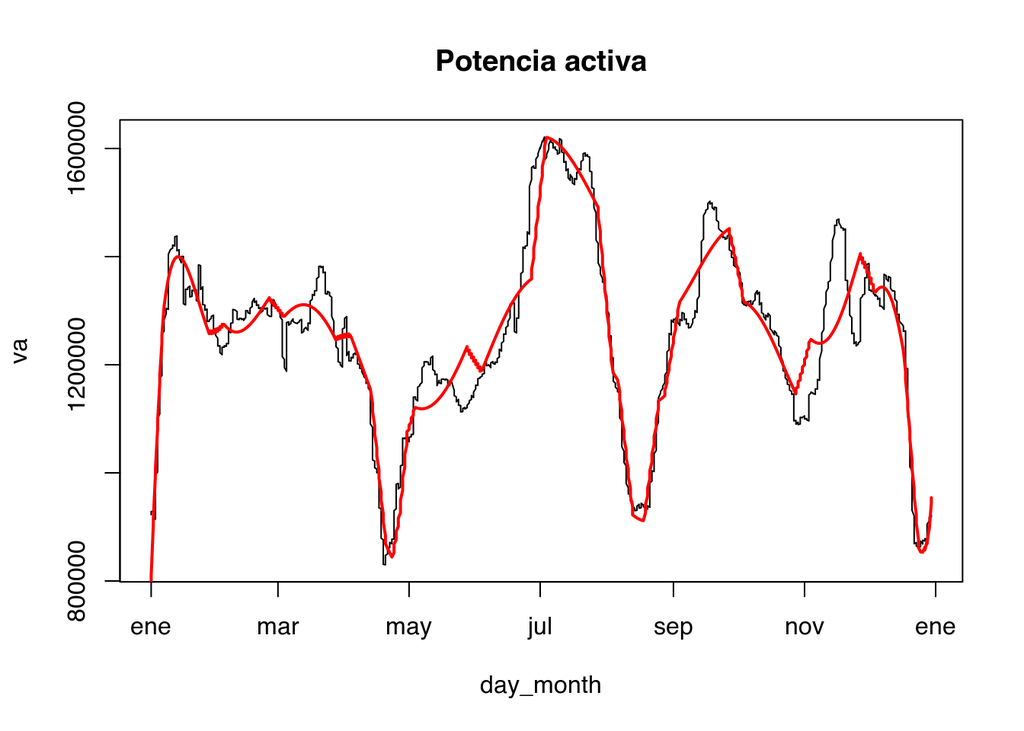

```r
# AVERAGE
t = rep(c(1:364),each=2)
t2=t^2;t3=t^3;t4=t^4;t5=t^5;t6=t^6;t8=t^8;t10=t^10;t12=t^12;t14=t^14;t16=t^16
quadraticmodel <- lm(VA_BAU_avg~t+t2+t3+t4+t5+t6+t8+t10+t12+t14+t16+
                     vacaciones_dummy_avg+m1_dummy_avg+m3_dummy_avg+m5_dummy_avg+m7_dummy_avg+m9_dummy_avg+m11_dummy_avg)
plot(day_month, VA_BAU_avg, type="l", main = "Potencia activa", ylab="va")
lines(day_month, quadraticmodel$fit, col=2, lwd=2)
```

Así, si quisieramos un modelo que nos permitiera predecir el valor de cada punto con la granularidad de los datos (i.e. día del año + periodo tarde/mañana), usaríamos la siguiente parametrización:

$VA = DummyCiclo_{BAU}·Modelo_{BAU} + DummyCiclo_{EstadoAlarma}·Modelo_{EstadoAlarma} + DummyCiclo_{Pandemia}·Modelo_{Pandemia}$

Nosotros sólo hemos desarrollado el $Modelo_{BAU}$, los otros se harían igual.

$Modelo_{BAU} = ModeloCuadrático*(DummyManana*\beta_1 + DummyWeekdayTarde*\beta_2 + DummyWeekendTarde*\beta_3)$

Donde $ModeloCuadrático$ viene dado por la función que acabamos de ajustar (que es función del dia del año (t) y las dummies).

Los coeficientes $\beta_{i}$ se podrían calcular ajustando otro modelo o simplemente como la media de dicho ratio en la serie histórica. Como hemos observado en la sección de análisis, por la mañana no hay diferencia entre semana y fin de semana, así que esa es la razón por la que sólo usamos una dummy y un coeficiente para la mañana.

## Test

Como periodo de test cogemos los meses de enero - febrero 2021, que son dos meses que no hemos usado para crear el modelo, que se corresponden con un ciclo BAU (aunque como decíamos antes, esta última afirmación no tenemos datos suficientes para asegurarla).

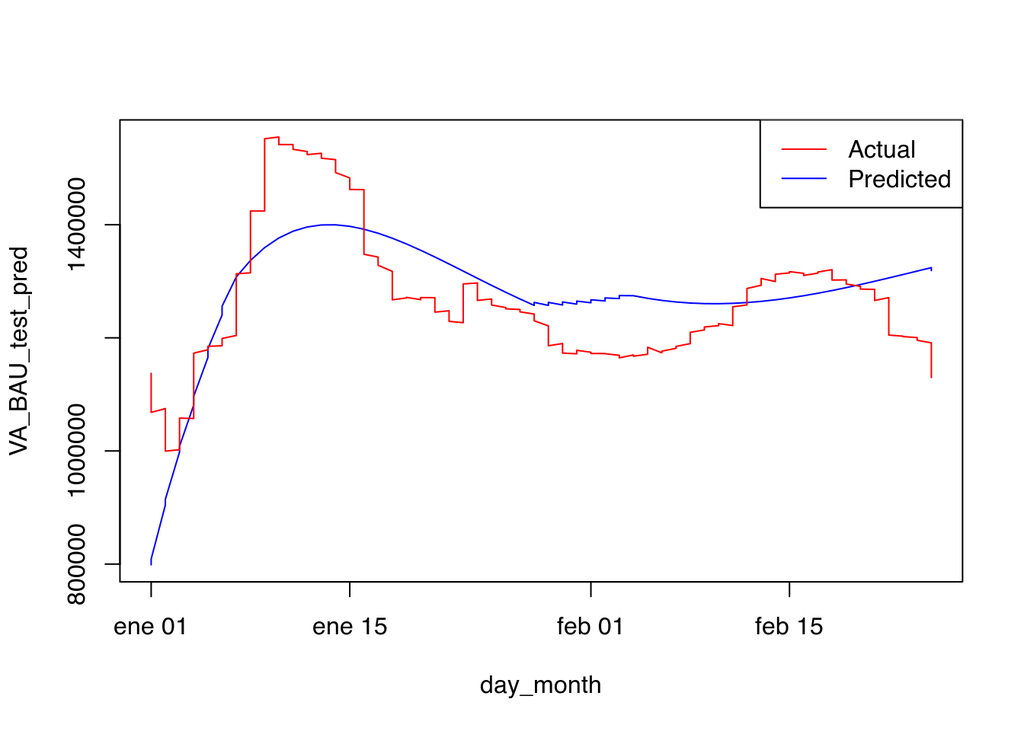

```r
t <- as.POSIXlt(serie$Time, format = "%Y-%m-%dT%H:%M:%S")
VA_BAU_test = VA[t$year == 121 & (t$mon <= 1)]
VA_BAU_test = VA_BAU_test[1:112]
VA_BAU_test_avg<-filter(VA_BAU_test,filter=rep(1/14,14), circular = TRUE)

idx = length(VA_BAU_test)
t_BAU_test = t[t$year == 121 & (t$mon <= 1)]
t_BAU_test = t_BAU_test[1:112]

t = rep(c(1:(idx/2)),each=2)
t2=t^2;t3=t^3;t4=t^4;t5=t^5;t6=t^6;t8=t^8;t10=t^10;t12=t^12;t14=t^14;t16=t^16
m1_dummy_avg = m1_dummy_avg[1:idx]
m3_dummy_avg = m3_dummy_avg[1:idx]
m5_dummy_avg = m5_dummy_avg[1:idx]
m7_dummy_avg = m7_dummy_avg[1:idx]
m9_dummy_avg = m9_dummy_avg[1:idx]
m11_dummy_avg = m11_dummy_avg[1:idx]
vacaciones_dummy_avg = vacaciones_dummy_avg[1:idx]
testdata = data.frame(t,t2,t3,t4,t5,t6,t8,t10,t12,t14,t16,vacaciones_dummy_avg,m1_dummy_avg,m3_dummy_avg,m5_dummy_avg,
                      m7_dummy_avg,m9_dummy_avg,m11_dummy_avg)
VA_BAU_test_pred = predict(quadraticmodel, testdata)
day_month = as.Date(t, origin = "2020/12/31") # El año nos da igual
plot(day_month,VA_BAU_test_pred,type="l",col="blue",ylim=c(min(VA_BAU_test_pred),max(VA_BAU_test_avg)))
lines(day_month,VA_BAU_test_avg,col="red")
legend("topright", legend=c("Actual", "Predicted"), lty=1, col=c("red", "blue"))
```

Veamos el error. Usamos los errores absolutos (en porcentaje y en desviación absoluta) porque nos parecen más interpretables que los cuadrados.

```r
sum(abs((VA_BAU_test_pred-VA_BAU_test_avg)/VA_BAU_test_avg))/idx*100 #MAPE
```

```
## [1] 5.781451
```

```r
sum(abs((VA_BAU_test_pred-VA_BAU_test_avg)))/idx #MAD
```

```
## [1] 72735.89
```

La desviación media es del 5.8%. No está mal!

$\blacksquare$